# Математически основи на музиката

## 3. Музикални интервали и комплексни числа

### 3.1 Представяне на синусоиди чрез комплексни числа

Съгласно формулата на Ойлер: $e^{i\theta} = \cos(\theta) + i\sin(\theta)$

Синусоидалните звукови вълни могат да бъдат представени като:

$$z(t) = A \cdot e^{i(2\pi\nu t + \phi)} = A \cdot e^{i\phi} \cdot e^{i2\pi\nu t}$$

#### Разлагане на комплексната синусоида

Използвайки формулата на Ойлер, можем да разложим комплексната синусоида:

$$z(t) = A \cdot e^{i(2\pi\nu t + \phi)} = A[\cos(2\pi\nu t + \phi) + i\sin(2\pi\nu t + \phi)]$$

**Реална част (действителна синусоида):** $$\text{Re}[z(t)] = A\cos(2\pi\nu t + \phi)$$

**Имагинерна част (коsinусоида с фазово изместване):** $$\text{Im}[z(t)] = A\sin(2\pi\nu t + \phi)$$

**Магнитуд (амплитуда):** $$|z(t)| = \sqrt{[\text{Re}[z(t)]]^2 + [\text{Im}[z(t)]]^2} = A$$

**Фаза:** $$\arg[z(t)] = \arctan\left(\frac{\text{Im}[z(t)]}{\text{Re}[z(t)]}\right) = 2\pi\nu t + \phi$$

Това представяне ни позволява лесно да анализираме фазовите отношения между различни тонове.

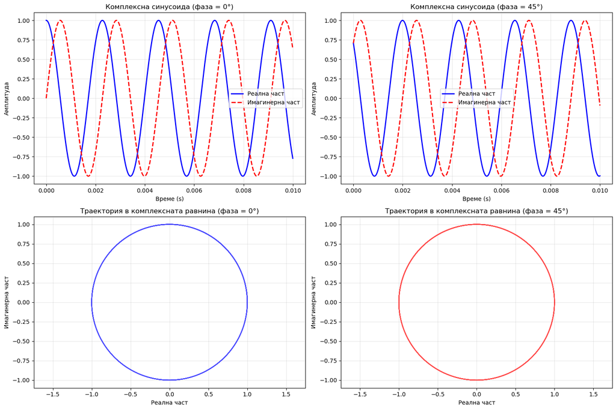

```python
import numpy as np
import matplotlib.pyplot as plt

# Функция за генериране на комплексна синусоида
def complex_sinusoid(frequency, phase, amplitude=1, duration=1, sample_rate=44100):
    """Генерира комплексна синусоида"""
    t = np.linspace(0, duration, int(sample_rate * duration), False)
    return amplitude * np.exp(1j * (2 * np.pi * frequency * t + phase))

# Създаване на две вълни с различни фази
freq = 440  # A4
phase1 = 0
phase2 = np.pi/4  # 45 градуса

wave1 = complex_sinusoid(freq, phase1, duration=0.01)
wave2 = complex_sinusoid(freq, phase2, duration=0.01)
t = np.linspace(0, 0.01, len(wave1))

# Визуализация на реалните и имагинерните части
fig, axes = plt.subplots(2, 2, figsize=(15, 10))

# Първа вълна
axes[0,0].plot(t, np.real(wave1), 'b-', label='Реална част', linewidth=2)
axes[0,0].plot(t, np.imag(wave1), 'r--', label='Имагинерна част', linewidth=2)
axes[0,0].set_title(f'Комплексна синусоида (фаза = 0°)')
axes[0,0].set_xlabel('Време (s)')
axes[0,0].set_ylabel('Амплитуда')  # ← ДОБАВЕН ЕТИКЕТ
axes[0,0].legend()
axes[0,0].grid(True, alpha=0.3)

# Втора вълна
axes[0,1].plot(t, np.real(wave2), 'b-', label='Реална част', linewidth=2)
axes[0,1].plot(t, np.imag(wave2), 'r--', label='Имагинерна част', linewidth=2)
axes[0,1].set_title(f'Комплексна синусоида (фаза = 45°)')
axes[0,1].set_xlabel('Време (s)')
axes[0,1].set_ylabel('Амплитуда')  # ← ДОБАВЕН ЕТИКЕТ
axes[0,1].legend()
axes[0,1].grid(True, alpha=0.3)

# Комплексна равнина - първа вълна
axes[1,0].plot(np.real(wave1), np.imag(wave1), 'b-', alpha=0.7)
axes[1,0].set_title('Траектория в комплексната равнина (фаза = 0°)')
axes[1,0].set_xlabel('Реална част')
axes[1,0].set_ylabel('Имагинерна част')
axes[1,0].grid(True, alpha=0.3)
axes[1,0].axis('equal')

# Комплексна равнина - втора вълна
axes[1,1].plot(np.real(wave2), np.imag(wave2), 'r-', alpha=0.7)
axes[1,1].set_title('Траектория в комплексната равнина (фаза = 45°)')
axes[1,1].set_xlabel('Реална част')
axes[1,1].set_ylabel('Имагинерна част')
axes[1,1].grid(True, alpha=0.3)
axes[1,1].axis('equal')

plt.tight_layout()
plt.show()
```

### 3.2 Анализ на хармонии чрез комплексни числа

Когато няколко тона звучат едновременно, техните комплексни представяния се сумират.

**Математическа формула за хармония:**

За $n$ тона с честоти $f_1, f_2, \ldots, f_n$ и амплитуди $A_1, A_2, \ldots, A_n$:

$$z_{harmony}(t) = \sum_{i=1}^{n} A_i \cdot e^{j(2\pi f_i t + \varphi_i)}$$

където $\varphi_i$ са началните фази на отделните тонове.

**Амплитуда на резултантния сигнал:** $$|z_{harmony}(t)| = \left|\sum_{i=1}^{n} A_i \cdot e^{j(2\pi f_i t + \varphi_i)}\right|$$

**Мощност на хармонията:** $$P_{harmony}(t) = |z_{harmony}(t)|^2 = z_{harmony}(t) \cdot z_{harmony}^*(t)$$

където $z^*$ означава комплексно спрегнатото число.

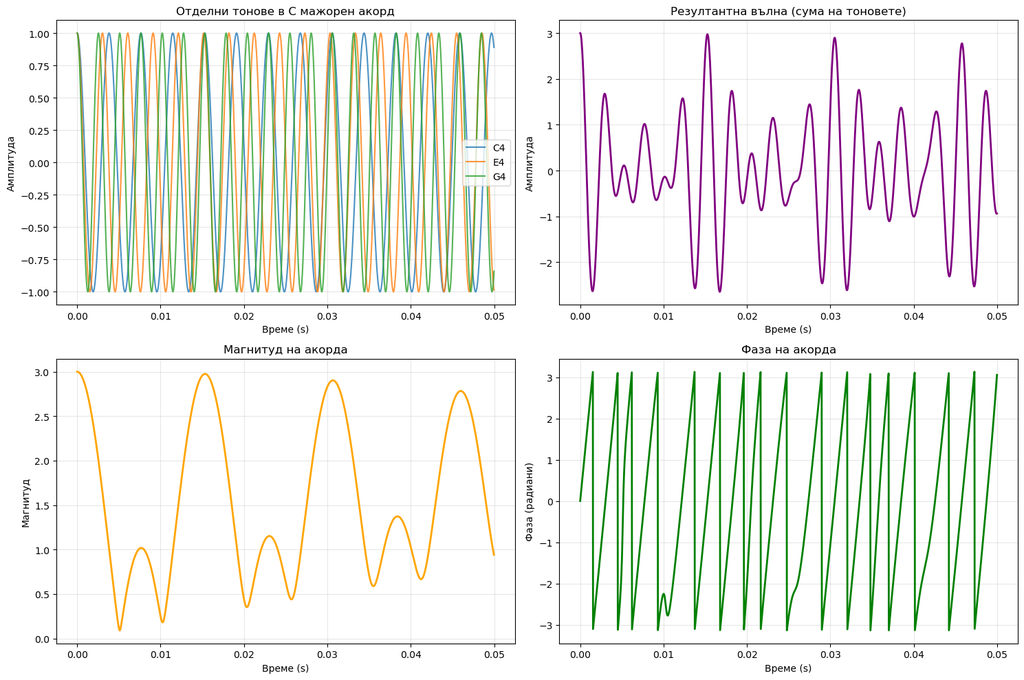

```
Математически анализ на C мажорния акорд:
  Среден магнитуд: 1.548
  Средна мощност: 3.120
  Максимална мощност: 9.000
  RMS амплитуда: 1.766

Проверка: √(средна мощност) = 1.766
          среден магнитуд = 1.548
```

```python
# Анализ на мажорен акорд (C-E-G)
def analyze_chord(frequencies, duration=1.0, sample_rate=44100):
    """Анализира акорд чрез комплексни числа"""
    t = np.linspace(0, duration, int(sample_rate * duration), False)

    # Генериране на отделните тонове
    tones = []
    for freq in frequencies:
        tone = np.exp(1j * 2 * np.pi * freq * t)
        tones.append(tone)

    # Сумиране на тоновете
    chord = sum(tones)

    return t, tones, chord

# C мажорен акорд (приблизителни честоти)
c_major_freqs = [261.63, 329.63, 392.00]  # C4, E4, G4
note_names = ['C4', 'E4', 'G4']

t, individual_tones, chord = analyze_chord(c_major_freqs, duration=0.05)

# Визуализация С ПРАВИЛНИ ЕТИКЕТИ
fig, axes = plt.subplots(2, 2, figsize=(15, 10))

# Отделни тонове
axes[0,0].plot(t, np.real(individual_tones[0]), label='C4', alpha=0.8)
axes[0,0].plot(t, np.real(individual_tones[1]), label='E4', alpha=0.8)
axes[0,0].plot(t, np.real(individual_tones[2]), label='G4', alpha=0.8)
axes[0,0].set_title('Отделни тонове в C мажорен акорд')
axes[0,0].set_xlabel('Време (s)')
axes[0,0].set_ylabel('Амплитуда')  # ← ДОБАВЕН ЕТИКЕТ
axes[0,0].legend()
axes[0,0].grid(True, alpha=0.3)

# Резултантна вълна
axes[0,1].plot(t, np.real(chord), 'purple', linewidth=2)
axes[0,1].set_title('Резултантна вълна (сума на тоновете)')
axes[0,1].set_xlabel('Време (s)')
axes[0,1].set_ylabel('Амплитуда')  # ← ДОБАВЕН ЕТИКЕТ
axes[0,1].grid(True, alpha=0.3)

# Магнитуд на комплексния акорд
axes[1,0].plot(t, np.abs(chord), 'orange', linewidth=2)
axes[1,0].set_title('Магнитуд на акорда')
axes[1,0].set_xlabel('Време (s)')
axes[1,0].set_ylabel('Магнитуд')  # ← ДОБАВЕН ЕТИКЕТ
axes[1,0].grid(True, alpha=0.3)

# Фаза на комплексния акорд
axes[1,1].plot(t, np.angle(chord), 'green', linewidth=2)
axes[1,1].set_title('Фаза на акорда')
axes[1,1].set_xlabel('Време (s)')
axes[1,1].set_ylabel('Фаза (радиани)')  # ← ТОЗИ ВЕЧЕ БЕ ДОБАВЕН
axes[1,1].grid(True, alpha=0.3)

plt.tight_layout()
plt.show()

# Математически анализ на хармонията
mean_magnitude = np.mean(np.abs(chord))
chord_power = np.abs(chord)**2  # P = |z|²
mean_power = np.mean(chord_power)
max_power = np.max(chord_power)

print("Математически анализ на C мажорния акорд:")
print(f"  Среден магнитуд: {mean_magnitude:.3f}")
print(f"  Средна мощност: {mean_power:.3f}")
print(f"  Максимална мощност: {max_power:.3f}")
print(f"  RMS амплитуда: {np.sqrt(mean_power):.3f}")

# Връзка между магнитуд и мощност
print(f"\nПроверка: √(средна мощност) = {np.sqrt(mean_power):.3f}")
print(f"          среден магнитуд = {mean_magnitude:.3f}")
```

### 3.3 Биения и интерференция

Когато два тона с близки честоти се комбинират, възникват биения - периодични промени в силата на звука.

**Математическа формула за биения:**

За два тона с честоти $f_1$ и $f_2$ (където $f_1 \approx f_2$):

$$z_1(t) = A_1 \cdot e^{j2\pi f_1 t}$$$$z_2(t) = A_2 \cdot e^{j2\pi f_2 t}$$

**Комбинираният сигнал:** $$z_{total}(t) = z_1(t) + z_2(t) = A_1 e^{j2\pi f_1 t} + A_2 e^{j2\pi f_2 t}$$

**Честота на биенията:** $$f_{beat} = |f_1 - f_2|$$

**Амплитуда на биенията:** $$A_{beat}(t) = |A_1 e^{j2\pi f_1 t} + A_2 e^{j2\pi f_2 t}|$$

**При еднакви амплитуди** ($A_1 = A_2 = A$): $$A_{beat}(t) = 2A \left|\cos\left(\pi (f_1 - f_2) t\right)\right|$$

**Период на биенията:** $$T_{beat} = \frac{1}{f_{beat}} = \frac{1}{|f_1 - f_2|}$$

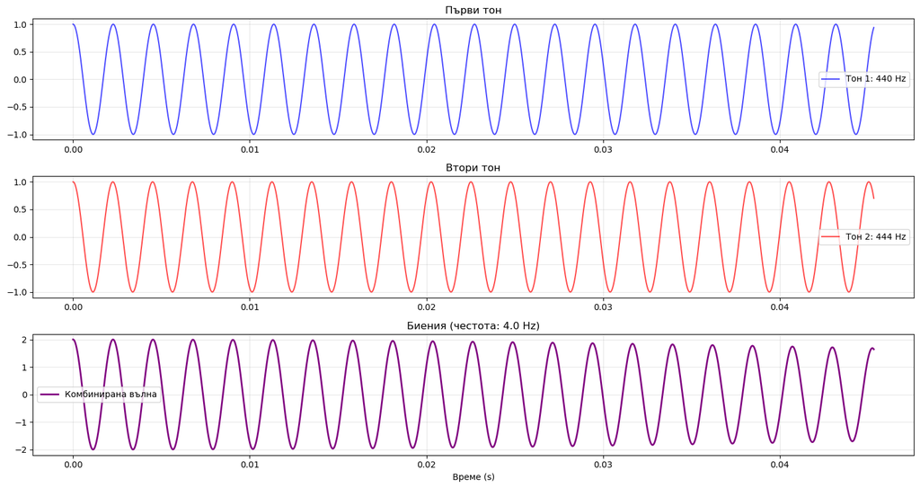

```
Теоретична честота на биенията: 4 Hz
Период на биенията: 0.250 секунди
```

```python
# Демонстрация на биения
def demonstrate_beats(freq1, freq2, duration=2.0, sample_rate=44100):
    """Демонстрира биения между два тона"""
    t = np.linspace(0, duration, int(sample_rate * duration), False)

    # Генериране на двата тона
    tone1 = np.cos(2 * np.pi * freq1 * t)
    tone2 = np.cos(2 * np.pi * freq2 * t)

    # Комбинирана вълна
    combined = tone1 + tone2

    # Теоретична честота на биенията
    beat_frequency = abs(freq2 - freq1)

    return t, tone1, tone2, combined, beat_frequency

# Пример с близки честоти
f1 = 440  # A4
f2 = 444  # Малко по-висок тон

t, tone1, tone2, beats, beat_freq = demonstrate_beats(f1, f2, duration=1.0)

# Визуализация
plt.figure(figsize=(15, 8))

plt.subplot(3, 1, 1)
plt.plot(t[:2000], tone1[:2000], 'b-', label=f'Тон 1: {f1} Hz', alpha=0.7)
plt.title('Първи тон')
plt.legend()
plt.grid(True, alpha=0.3)

plt.subplot(3, 1, 2)
plt.plot(t[:2000], tone2[:2000], 'r-', label=f'Тон 2: {f2} Hz', alpha=0.7)
plt.title('Втори тон')
plt.legend()
plt.grid(True, alpha=0.3)

plt.subplot(3, 1, 3)
plt.plot(t[:2000], beats[:2000], 'purple', linewidth=2, label='Комбинирана вълна')
plt.title(f'Биения (честота: {beat_freq:.1f} Hz)')
plt.xlabel('Време (s)')
plt.legend()
plt.grid(True, alpha=0.3)

plt.tight_layout()
plt.show()

print(f"Теоретична честота на биенията: {beat_freq} Hz")
print(f"Период на биенията: {1/beat_freq:.3f} секунди")
```

### 4.1 Представяне на акорди като вектори

#### Математическо описание на хроматичното векторно пространство

Всеки акорд може да бъде представен като вектор в 12-мерното хроматично пространство:

$$\mathbf{v} = (v_0, v_1, v_2, \ldots, v_{11}) \in \{0,1\}^{12}$$

където $v_i = 1$ ако нотата $i$ присъства в акорда, и $v_i = 0$ в противен случай.

**Основни векторни операции:**

**Норма на вектора (брой ноти в акорда):** $$\|\mathbf{v}\|_1 = \sum_{i=0}^{11} v_i$$

**Евклидова норма:** $$\|\mathbf{v}\|_2 = \sqrt{\sum_{i=0}^{11} v_i^2}$$

**Косинусово сходство между два акорда:** $$\text{sim}(\mathbf{u}, \mathbf{v}) = \frac{\mathbf{u} \cdot \mathbf{v}}{\|\mathbf{u}\|_2 \|\mathbf{v}\|_2} = \frac{\sum_{i=0}^{11} u_i v_i}{\sqrt{\sum_{i=0}^{11} u_i^2} \sqrt{\sum_{i=0}^{11} v_i^2}}$$

```
Полярни диаграми...
```

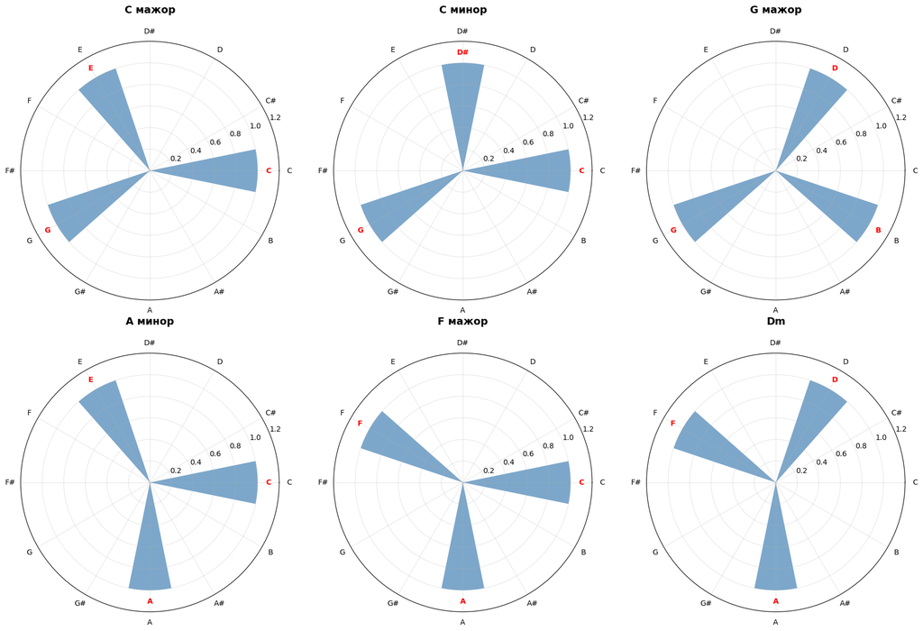

```
Радарни диаграми...
```

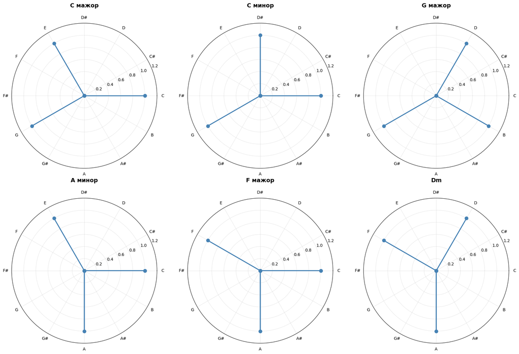

```
2D векторно представяне...
```

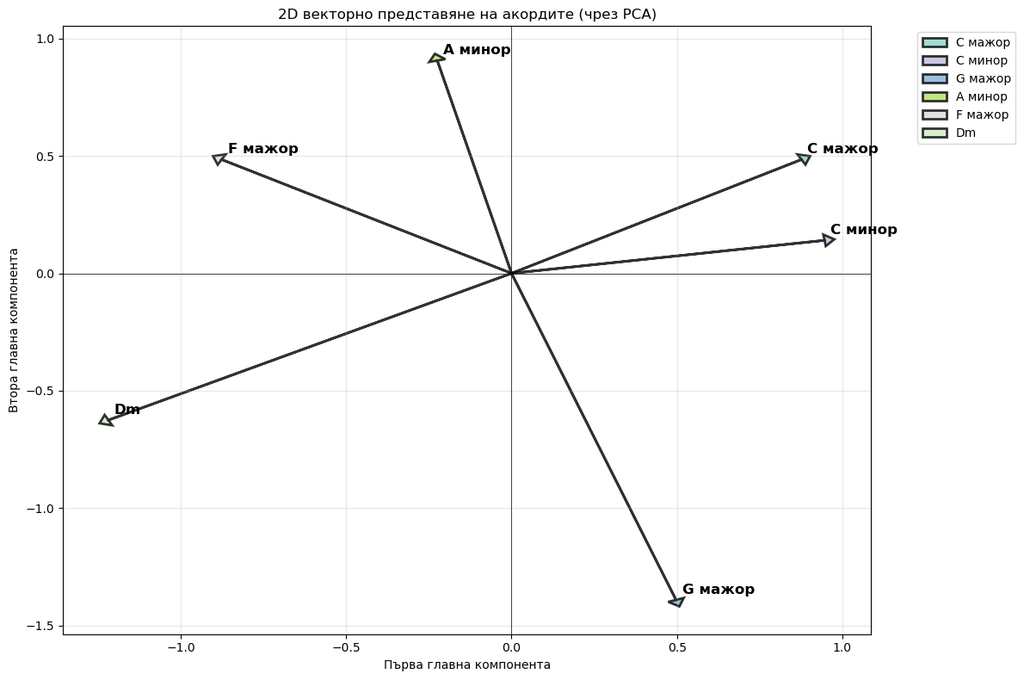

```
Вариация от PCA: [0.42143197 0.36329932]
Обща вариация: 0.785
3D векторно представяне...
```

[figure not shown]

```
3D вариация: [0.42143197 0.36329932 0.14608111]
3D обща вариация: 0.931
```

```python
import numpy as np
import matplotlib.pyplot as plt
from scipy.spatial.distance import cosine
from mpl_toolkits.mplot3d import Axes3D

# Функция за създаване на хроматичен вектор
def create_chromatic_vector(notes):
    """
    Създава 12-мерен хроматичен вектор за даден акорд
    notes: списък от ноти като числа (0=C, 1=C#, 2=D, ...)
    """
    vector = np.zeros(12)
    for note in notes:
        vector[note % 12] = 1
    return vector

# Дефиниране на основни акорди
chord_definitions = {
    'C мажор': [0, 4, 7],      # C-E-G
    'C минор': [0, 3, 7],      # C-Eb-G
    'G мажор': [7, 11, 2],     # G-B-D
    'A минор': [9, 0, 4],      # A-C-E
    'F мажор': [5, 9, 0],      # F-A-C
    'Dm': [2, 5, 9],           # D-F-A
}

# Генериране на векторите за акордите
chord_vectors = {}
for chord_name, notes in chord_definitions.items():
    chord_vectors[chord_name] = create_chromatic_vector(notes)

note_names = ['C', 'C#', 'D', 'D#', 'E', 'F', 'F#', 'G', 'G#', 'A', 'A#', 'B']

# 1. ПОЛЯРНА ДИАГРАМА (Хроматичен кръг)
print("Полярни диаграми...")
fig, axes = plt.subplots(2, 3, figsize=(18, 12), subplot_kw=dict(projection='polar'))
axes = axes.flatten()

# Ъгли за 12-те полутона (360° / 12 = 30° между всеки)
angles = np.linspace(0, 2 * np.pi, 12, endpoint=False)

for i, (chord_name, vector) in enumerate(chord_vectors.items()):
    ax = axes[i]

    # Създаване на полярна диаграма
    bars = ax.bar(angles, vector, width=0.4, alpha=0.7, color='steelblue')

    # Настройки
    ax.set_title(f'{chord_name}', pad=20, fontsize=14, fontweight='bold')
    ax.set_thetagrids(np.degrees(angles), note_names)
    ax.set_ylim(0, 1.2)
    ax.grid(True, alpha=0.3)

    # Маркиране на активните ноти
    for j, (angle, val) in enumerate(zip(angles, vector)):
        if val > 0:
            ax.annotate(note_names[j], (angle, val + 0.1),
                       ha='center', va='center', fontweight='bold', color='red')

plt.tight_layout()
plt.show()

# 2. РАДАРНА ДИАГРАМА
print("Радарни диаграми...")
fig, axes = plt.subplots(2, 3, figsize=(18, 12), subplot_kw=dict(projection='polar'))
axes = axes.flatten()

for i, (chord_name, vector) in enumerate(chord_vectors.items()):
    ax = axes[i]

    # Добавяне на първата точка накрая за затваряне на формата
    values = np.concatenate([vector, [vector[0]]])
    angles_closed = np.concatenate([angles, [angles[0]]])

    # Изчертаване на радарната диаграма
    ax.plot(angles_closed, values, 'o-', linewidth=2, color='steelblue', markersize=8)
    ax.fill(angles_closed, values, alpha=0.25, color='steelblue')

    ax.set_title(f'{chord_name}', pad=20, fontsize=14, fontweight='bold')
    ax.set_thetagrids(np.degrees(angles), note_names)
    ax.set_ylim(0, 1.2)
    ax.grid(True, alpha=0.3)

plt.tight_layout()
plt.show()

# 3. ВЕКТОРНО ПОЛЕ В 2D (използвайки PCA за намаляване на размерността)
print("2D векторно представяне...")
from sklearn.decomposition import PCA

# Подготовка на данните за PCA
vectors_matrix = np.array(list(chord_vectors.values()))
chord_names = list(chord_vectors.keys())

# Приложение на PCA за намаляване до 2D
pca = PCA(n_components=2)
vectors_2d = pca.fit_transform(vectors_matrix)

# Визуализация в 2D
plt.figure(figsize=(12, 8))

# Изчертаване на векторите като стрелки от произход
for i, (name, vec_2d) in enumerate(zip(chord_names, vectors_2d)):
    plt.arrow(0, 0, vec_2d[0], vec_2d[1],
              head_width=0.05, head_length=0.03,
              fc=plt.cm.Set3(i/len(chord_names)),
              ec='black', linewidth=2, alpha=0.8,
              label=name)

    # Надписване на векторите
    plt.annotate(name, (vec_2d[0], vec_2d[1]),
                xytext=(5, 5), textcoords='offset points',
                fontsize=12, fontweight='bold')

plt.grid(True, alpha=0.3)
plt.axhline(y=0, color='k', linewidth=0.5)
plt.axvline(x=0, color='k', linewidth=0.5)
plt.xlabel('Първа главна компонента')
plt.ylabel('Втора главна компонента')
plt.title('2D векторно представяне на акордите (чрез PCA)')
plt.legend(bbox_to_anchor=(1.05, 1), loc='upper left')
plt.tight_layout()
plt.show()

print(f"Вариация от PCA: {pca.explained_variance_ratio_}")
print(f"Обща вариация: {sum(pca.explained_variance_ratio_):.3f}")

# 4. 3D ВЕКТОРНА ВИЗУАЛИЗАЦИЯ
print("3D векторно представяне...")
# PCA за 3D
pca_3d = PCA(n_components=3)
vectors_3d = pca_3d.fit_transform(vectors_matrix)

fig = plt.figure(figsize=(12, 8))
ax = fig.add_subplot(111, projection='3d')

# Изчертаване на 3D векторите
for i, (name, vec_3d) in enumerate(zip(chord_names, vectors_3d)):
    ax.quiver(0, 0, 0, vec_3d[0], vec_3d[1], vec_3d[2],
              color=plt.cm.Set3(i/len(chord_names)),
              arrow_length_ratio=0.1, linewidth=3, alpha=0.8)

    # Надписване
    ax.text(vec_3d[0], vec_3d[1], vec_3d[2], name, fontsize=12, fontweight='bold')

ax.set_xlabel('Първа главна компонента')
ax.set_ylabel('Втора главна компонента')
ax.set_zlabel('Трета главна компонента')
ax.set_title('3D векторно представяне на акордите')
plt.show()

print(f"3D вариация: {pca_3d.explained_variance_ratio_}")
print(f"3D обща вариация: {sum(pca_3d.explained_variance_ratio_):.3f}")
```

### 4.2 Анализ на хармоничните отношения чрез векторни операции

#### Математически метрики за сходство между акорди

**Косинусово разстояние:** $$d_{cosine}(\mathbf{u}, \mathbf{v}) = 1 - \frac{\mathbf{u} \cdot \mathbf{v}}{\|\mathbf{u}\|_2 \|\mathbf{v}\|_2}$$

**Хамингово разстояние (брой различни ноти):** $$d_{Hamming}(\mathbf{u}, \mathbf{v}) = \sum_{i=0}^{11} |u_i - v_i|$$

**Евклидово разстояние:** $$d_{Euclidean}(\mathbf{u}, \mathbf{v}) = \sqrt{\sum_{i=0}^{11} (u_i - v_i)^2}$$

**Жакардов коефициент (за двоични вектори):** $$J(\mathbf{u}, \mathbf{v}) = \frac{|\mathbf{u} \cap \mathbf{v}|}{|\mathbf{u} \cup \mathbf{v}|} = \frac{\sum_{i=0}^{11} u_i v_i}{\sum_{i=0}^{11} \max(u_i, v_i)}$$

**Дайсов коефициент:** $$D(\mathbf{u}, \mathbf{v}) = \frac{2|\mathbf{u} \cap \mathbf{v}|}{|\mathbf{u}| + |\mathbf{v}|} = \frac{2\sum_{i=0}^{11} u_i v_i}{\sum_{i=0}^{11} u_i + \sum_{i=0}^{11} v_i}$$

Използвайки векторни операции, можем да анализираме сходството между акорди и да прогнозираме хармоничните прогресии.

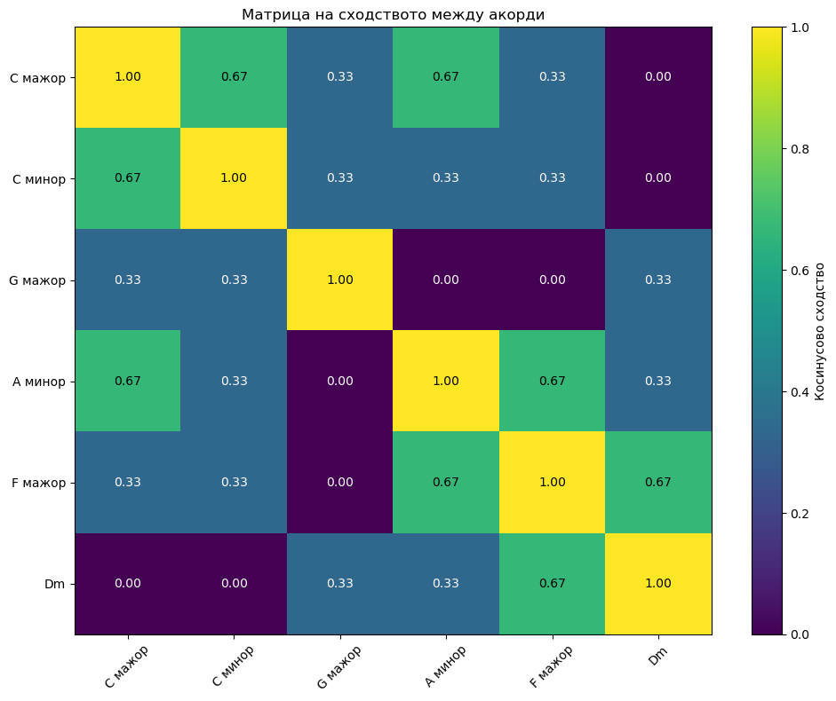

```
Най-сходни двойки акорди (без идентичните):
--------------------------------------------------
C мажор ↔ C минор: 0.667
C мажор ↔ G мажор: 0.333
C мажор ↔ A минор: 0.667
C мажор ↔ F мажор: 0.333
C мажор ↔ Dm: 0.000
C минор ↔ G мажор: 0.333
C минор ↔ A минор: 0.333
C минор ↔ F мажор: 0.333
C минор ↔ Dm: 0.000
G мажор ↔ A минор: 0.000
G мажор ↔ F мажор: 0.000
G мажор ↔ Dm: 0.333
A минор ↔ F мажор: 0.667
A минор ↔ Dm: 0.333
F мажор ↔ Dm: 0.667

Дендрограма...
```

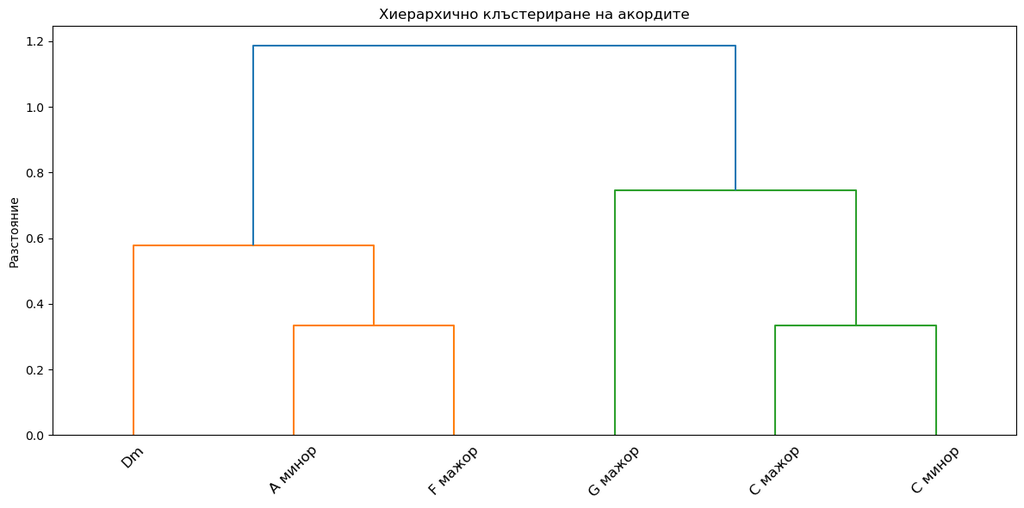

```python
# Изчисляване на сходства между акорди
def chord_similarity_analysis(chord_vectors):
    """Анализира сходството между акорди"""
    chord_names = list(chord_vectors.keys())
    n_chords = len(chord_names)

    # Матрица на сходството (косинусово сходство)
    similarity_matrix = np.zeros((n_chords, n_chords))

    for i, chord1 in enumerate(chord_names):
        for j, chord2 in enumerate(chord_names):
            v1 = chord_vectors[chord1]
            v2 = chord_vectors[chord2]

            # Косинусово сходство (1 - косинусово разстояние)
            similarity = 1 - cosine(v1, v2) if np.any(v1) and np.any(v2) else 0
            similarity_matrix[i, j] = similarity

    return similarity_matrix, chord_names

# Изчисляване на сходството
sim_matrix, chord_names = chord_similarity_analysis(chord_vectors)

# Визуализация на матрицата на сходството
plt.figure(figsize=(10, 8))
im = plt.imshow(sim_matrix, cmap='viridis', aspect='auto')
plt.colorbar(im, label='Косинусово сходство')
plt.title('Матрица на сходството между акорди')
plt.xticks(range(len(chord_names)), chord_names, rotation=45)
plt.yticks(range(len(chord_names)), chord_names)

# Добавяне на числови стойности в клетките
for i in range(len(chord_names)):
    for j in range(len(chord_names)):
        plt.text(j, i, f'{sim_matrix[i, j]:.2f}',
                ha='center', va='center', color='white' if sim_matrix[i, j] < 0.5 else 'black')

plt.tight_layout()
plt.show()

# Намиране на най-сходните акорди
print("Най-сходни двойки акорди (без идентичните):")
print("-" * 50)
for i in range(len(chord_names)):
    for j in range(i+1, len(chord_names)):
        similarity = sim_matrix[i, j]
        print(f"{chord_names[i]} ↔ {chord_names[j]}: {similarity:.3f}")

# 6. ХИЕРАРХИЧНО КЛЪСТЕРИРАНЕ
print()
print("Дендрограма...")
from scipy.cluster.hierarchy import dendrogram, linkage
from scipy.spatial.distance import pdist

# Изчисляване на разстоянията
distances = pdist(vectors_matrix, metric='cosine')
linkage_matrix = linkage(distances, method='ward')

plt.figure(figsize=(12, 6))
dendrogram(linkage_matrix, labels=chord_names, leaf_rotation=45, leaf_font_size=12)
plt.title('Хиерархично клъстериране на акордите')
plt.ylabel('Разстояние')
plt.tight_layout()
plt.show()
```

### 4.3 Матрични трансформации в музиката

#### Математически основи на музикалните трансформации

Музикалните трансформации могат да бъдат представени като линейни трансформации в 12-мерното хроматично пространство.

**Общ вид на трансформационна матрица:** $$\mathbf{v}_{new} = \mathbf{T} \cdot \mathbf{v}_{old}$$

където $\mathbf{T} \in \mathbb{R}^{12 \times 12}$ е трансформационната матрица.

**1. Транспониране с $k$ полутона:** $$\mathbf{T}_k = \begin{pmatrix} 0 & 0 & \cdots & 0 & 1 & 0 & \cdots & 0 \\ \vdots & \vdots & \ddots & \vdots & \vdots & \vdots & \ddots & \vdots \\ 0 & 1 & \cdots & 0 & 0 & 0 & \cdots & 0 \end{pmatrix}$$

**2. Инверсия около център $c$:** $$\mathbf{I}_c: i \mapsto (2c - i) \bmod 12$$

Матричен елемент: $I_{ij} = 1$ ако $j = (2c - i) \bmod 12$, иначе $I_{ij} = 0$.

**3. Свойства на трансформационните матрици:**

- **Транспонирането е обратимо:** $\mathbf{T}_k \cdot \mathbf{T}_{-k} = \mathbf{I}$
- **Инверсията е самообратима:** $\mathbf{I}_c \cdot \mathbf{I}_c = \mathbf{I}$
- **Детерминанта:** $\det(\mathbf{T}_k) = (-1)^k$, $\det(\mathbf{I}_c) = -1$

**4. Композиция на трансформации:** $$\mathbf{T}_{composite} = \mathbf{T}_2 \cdot \mathbf{T}_1$$

Музикалните трансформации като транспониране, инверсия и ретроградация могат да бъдат представени като матрични операции.

```
Оригинален C мажор: [1 0 0 0 1 0 0 1 0 0 0 0]
Активни ноти: ['C', 'E', 'G']

Транспониран (+5 полутона): [0. 0. 1. 0. 0. 0. 0. 1. 0. 0. 0. 1.]
Активни ноти: ['D', 'G', 'B']

Инвертиран около C: [1. 0. 0. 0. 0. 1. 0. 0. 1. 0. 0. 0.]
Активни ноти: ['C', 'F', 'G#']

Инвертиран около F#: [1. 0. 0. 0. 0. 1. 0. 0. 1. 0. 0. 0.]
Активни ноти: ['C', 'F', 'G#']

Комбинирана (инверсия + транспониране): [1. 0. 0. 1. 0. 0. 0. 1. 0. 0. 0. 0.]
Активни ноти: ['C', 'D#', 'G']
```

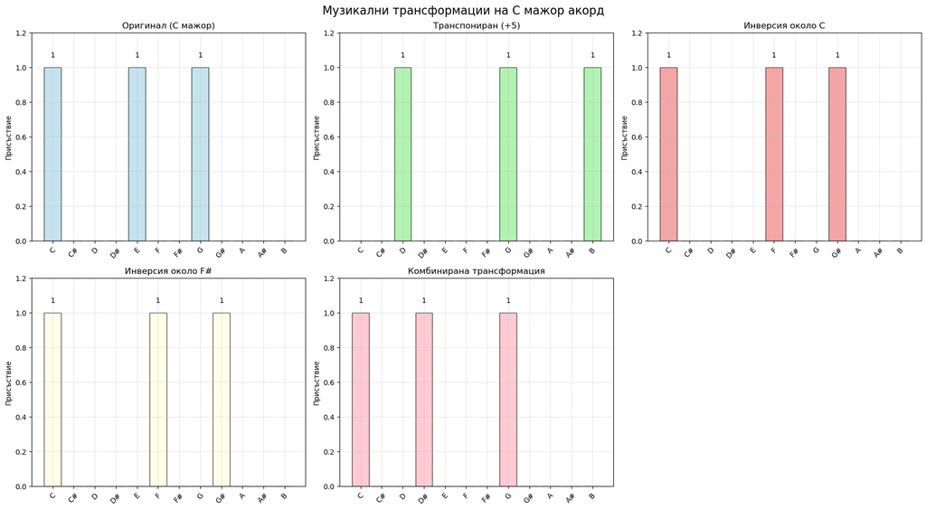

[output not shown]

```python
# Музикални трансформации

import numpy as np
import matplotlib.pyplot as plt

# Настройка на шрифт за български текст
plt.rcParams['font.family'] = 'DejaVu Sans'

# Дефиниране на нотите
note_names = ['C', 'C#', 'D', 'D#', 'E', 'F', 'F#', 'G', 'G#', 'A', 'A#', 'B']

# Дефиниране на акорди като вектори
chord_vectors = {
    'C мажор': np.array([1, 0, 0, 0, 1, 0, 0, 1, 0, 0, 0, 0]),  # C-E-G
    'A минор': np.array([1, 0, 0, 1, 0, 0, 0, 1, 0, 0, 0, 0]),  # A-C-E
    'G мажор': np.array([0, 0, 1, 0, 0, 0, 0, 1, 0, 0, 0, 1]),  # G-B-D
    'F мажор': np.array([1, 0, 0, 0, 0, 1, 0, 0, 0, 1, 0, 0])   # F-A-C
}

def create_transposition_matrix(semitones):
    """
    Създава матрица за транспониране с дадения брой полутонове

    Параметри:
    semitones: брой полутонове за транспониране (може да е отрицателен)
    """
    T = np.zeros((12, 12))
    for i in range(12):
        T[i, (i + semitones) % 12] = 1
    return T

def create_inversion_matrix(center=0):
    """
    Създава матрица за музикална инверсия около даден център

    Параметри:
    center: центърът на инверсията (по подразбиране 0 = C)

    Музикалната инверсия: ако интервалът нагоре е n полутона,
    инвертираният интервал надолу е същия брой полутона
    """
    I = np.zeros((12, 12))
    for i in range(12):
        # Инверсия: center - (i - center) = 2*center - i
        inverted_note = (2 * center - i) % 12
        I[i, inverted_note] = 1
    return I

def create_retrograde_matrix():
    """
    Създава матрица за ретроградна трансформация (обръщане на последователността)
    За акорди това не е много смислено, но е включено за пълнота
    """
    return np.flip(np.eye(12), axis=0)

# Анализ на трансформациите
def analyze_transformation(original, transformed, transformation_name):
    """Анализира взаимоврзката между оригинален и трансформиран акорд"""

    # Скаларно произведение
    dot_product = np.dot(original, transformed)

    # Евклидово разстояние
    euclidean_distance = np.linalg.norm(original - transformed)

    # Коефициент на сходство (косинус на ъгъла)
    norm_original = np.linalg.norm(original)
    norm_transformed = np.linalg.norm(transformed)

    if norm_original > 0 and norm_transformed > 0:
        similarity = dot_product / (norm_original * norm_transformed)
    else:
        similarity = 0

    print(f"\n{transformation_name}:")
    print(f"  Скаларно произведение: {dot_product}")
    print(f"  Евклидово разстояние: {euclidean_distance:.3f}")
    print(f"  Коефициент на сходство: {similarity:.3f}")

    return {
        'dot_product': dot_product,
        'distance': euclidean_distance,
        'similarity': similarity
    }

# Примери за трансформации
original_chord = chord_vectors['C мажор']
print(f"Оригинален C мажор: {original_chord}")
print(f"Активни ноти: {[note_names[i] for i in range(12) if original_chord[i] == 1]}")

# 1. Транспониране с 5 полутона (до F мажор)
T5 = create_transposition_matrix(5)
transposed_chord = T5 @ original_chord
print(f"\nТранспониран (+5 полутона): {transposed_chord}")
print(f"Активни ноти: {[note_names[i] for i in range(12) if transposed_chord[i] == 1]}")

# 2. Инверсия около C
I_C = create_inversion_matrix(0)
inverted_chord = I_C @ original_chord
print(f"\nИнвертиран около C: {inverted_chord}")
print(f"Активни ноти: {[note_names[i] for i in range(12) if inverted_chord[i] == 1]}")

# 3. Инверсия около F# (тритон)
I_Fs = create_inversion_matrix(6)
inverted_tritone = I_Fs @ original_chord
print(f"\nИнвертиран около F#: {inverted_tritone}")
print(f"Активни ноти: {[note_names[i] for i in range(12) if inverted_tritone[i] == 1]}")

# 4. Комбинирана трансформация (първо инверсия, после транспониране)
combined_transform = T5 @ I_C
combined_chord = combined_transform @ original_chord
print(f"\nКомбинирана (инверсия + транспониране): {combined_chord}")
print(f"Активни ноти: {[note_names[i] for i in range(12) if combined_chord[i] == 1]}")

# Визуализация на трансформациите
fig, axes = plt.subplots(2, 3, figsize=(18, 10))
fig.suptitle('Музикални трансформации на C мажор акорд', fontsize=16)

chords_to_plot = [
    ('Оригинал (C мажор)', original_chord, 'lightblue'),
    ('Транспониран (+5)', transposed_chord, 'lightgreen'),
    ('Инверсия около C', inverted_chord, 'lightcoral'),
    ('Инверсия около F#', inverted_tritone, 'lightyellow'),
    ('Комбинирана трансформация', combined_chord, 'lightpink'),
    ('Празно', np.zeros(12), 'white')  # За симетрия в решетката
]

for i, (title, chord, color) in enumerate(chords_to_plot):
    row, col = i // 3, i % 3
    if i < 5:  # Показваме само първите 5
        bars = axes[row, col].bar(range(12), chord, color=color, alpha=0.7, edgecolor='black')
        axes[row, col].set_title(title, fontsize=12)
        axes[row, col].set_xticks(range(12))
        axes[row, col].set_xticklabels(note_names, rotation=45)
        axes[row, col].set_ylabel('Присъствие')
        axes[row, col].set_ylim(0, 1.2)
        axes[row, col].grid(True, alpha=0.3)

        # Добавяме стойности над стълбовете
        for bar, val in zip(bars, chord):
            if val > 0:
                axes[row, col].text(bar.get_x() + bar.get_width()/2, val + 0.05,
                                   f'{val:.0f}', ha='center', va='bottom')
    else:
        axes[row, col].set_visible(False)

plt.tight_layout()
plt.show()

# Детайлен анализ на взаимовръзките
print("\n" + "="*60)
print("АНАЛИЗ НА МУЗИКАЛНИТЕ ТРАНСФОРМАЦИИ")
print("="*60)

transformations = [
    ("Транспониране (+5 полутона)", transposed_chord),
    ("Инверсия около C", inverted_chord),
    ("Инверсия около F#", inverted_tritone),
    ("Комбинирана трансформация", combined_chord)
]

analysis_results = {}
for name, chord in transformations:
    analysis_results[name] = analyze_transformation(original_chord, chord, name)

# Проверка на свойствата на матриците
print("\n" + "="*60)
print("СВОЙСТВА НА ТРАНСФОРМАЦИОННИТЕ МАТРИЦИ")
print("="*60)

# Проверка дали транспонирането е обратимо
T5_inverse = create_transposition_matrix(-5)
identity_check = T5 @ T5_inverse
print(f"\nТранспониране е обратимо: {np.allclose(identity_check, np.eye(12))}")

# Проверка дали инверсията е самообратима
I_squared = I_C @ I_C
print(f"Инверсията е самообратима: {np.allclose(I_squared, np.eye(12))}")

# Детерминанти на матриците
print(f"\nДетерминанта на T5: {np.linalg.det(T5):.3f}")
print(f"Детерминанта на I_C: {np.linalg.det(I_C):.3f}")

# Музикално-теоретични наблюдения
print("\n" + "="*60)
print("МУЗИКАЛНО-ТЕОРЕТИЧНИ НАБЛЮДЕНИЯ")
print("="*60)

print("\n1. Транспонирането запазва структурата на акорда")
print("   - C мажор (C-E-G) става F мажор (F-A-C)")
print("   - Интервалите остават същите")

print("\n2. Инверсията около C променя акорда:")
print("   - C остава на място (център на инверсията)")
print("   - E (4 полутона нагоре) става G# (4 полутона надолу)")
print("   - G (7 полутона нагоре) става F (5 полутона надолу)")

print("\n3. Коефициентът на сходство показва колко 'подобни' са акордите:")
for name, results in analysis_results.items():
    print(f"   - {name}: {results['similarity']:.3f}")

print("\n4. Математическите трансформации откриват скрити симетрии в музиката")
print("   - Групова теория в музикалния анализ")
print("   - Връзка между алгебра и хармония")
```

### 5.1 Fourier трансформация за спектрален анализ

#### Математически основи на Fourier анализа

**Дискретна Fourier трансформация (DFT):**

За дискретен сигнал $x[n]$ с $N$ проби:

$$X[k] = \sum_{n=0}^{N-1} x[n] \cdot e^{-j\frac{2\pi kn}{N}}, \quad k = 0, 1, \ldots, N-1$$

**Обратна DFT:** $$x[n] = \frac{1}{N} \sum_{k=0}^{N-1} X[k] \cdot e^{j\frac{2\pi kn}{N}}$$

**Честотни компоненти:** $$f[k] = \frac{k \cdot f_s}{N}$$

където $f_s$ е честотата на дискретизация.

**Магнитуден спектър:** $$|X[k]| = \sqrt{[\text{Re}(X[k])]^2 + [\text{Im}(X[k])]^2}$$

**Фазов спектър:** $$\phi[k] = \arctan\left(\frac{\text{Im}(X[k])}{\text{Re}(X[k])}\right)$$

**Мощностен спектър:** $$P[k] = |X[k]|^2 = X[k] \cdot X^*[k]$$

Fourier трансформацията ни позволява да разложим сложни музикални сигнали на техните честотни компоненти.

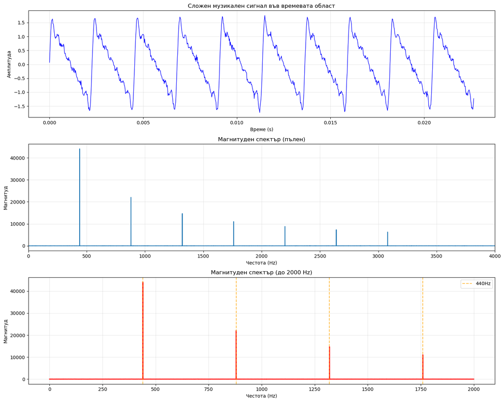

```
Доминантни честоти в сигнала:
-----------------------------------
  440.0 Hz: магнитуд    44108
  880.0 Hz: магнитуд    22064
 1320.0 Hz: магнитуд    14693
 1760.0 Hz: магнитуд    11037
 2200.0 Hz: магнитуд     8825
 2640.0 Hz: магнитуд     7343
```

```python
from scipy.io import wavfile
from scipy.fft import fft, fftfreq

# Генериране на сложен музикален сигнал
def generate_complex_signal(duration=2.0, sample_rate=44100):
    """Генерира сложен музикален сигнал с основен тон и хармоници"""
    t = np.linspace(0, duration, int(sample_rate * duration), False)

    # Основен тон (440 Hz)
    fundamental = np.sin(2 * np.pi * 440 * t)

    # Хармоници с намаляваща амплитуда
    harmonics = []
    for n in range(2, 8):  # хармоници от 2-ри до 7-ми
        amplitude = 1.0 / n  # амплитудата намалява с номера на хармониката
        harmonic = amplitude * np.sin(2 * np.pi * 440 * n * t)
        harmonics.append(harmonic)

    # Комбиниране на всички компоненти
    complex_signal = fundamental + sum(harmonics)

    # Добавяне на лек шум
    noise = 0.05 * np.random.randn(len(complex_signal))
    complex_signal += noise

    return t, complex_signal

# Генериране на сигнала
t, signal = generate_complex_signal()

# Fourier трансформация
signal_fft = fft(signal)
frequencies = fftfreq(len(signal), 1/44100)

# Магнитуд на спектъра
magnitude = np.abs(signal_fft)

# Визуализация
fig, axes = plt.subplots(3, 1, figsize=(15, 12))

# Времева област
axes[0].plot(t[:1000], signal[:1000], 'b-', linewidth=1)
axes[0].set_title('Сложен музикален сигнал във времевата област')
axes[0].set_xlabel('Време (s)')
axes[0].set_ylabel('Амплитуда')
axes[0].grid(True, alpha=0.3)

# Честотна област (пълен спектър)
positive_freq_idx = frequencies >= 0
axes[1].plot(frequencies[positive_freq_idx], magnitude[positive_freq_idx])
axes[1].set_title('Магнитуден спектър (пълен)')
axes[1].set_xlabel('Честота (Hz)')
axes[1].set_ylabel('Магнитуд')
axes[1].set_xlim(0, 4000)
axes[1].grid(True, alpha=0.3)

# Честотна област (увеличение до 2000 Hz)
freq_range = (frequencies >= 0) & (frequencies <= 2000)
axes[2].plot(frequencies[freq_range], magnitude[freq_range], 'r-', linewidth=2)
axes[2].set_title('Магнитуден спектър (до 2000 Hz)')
axes[2].set_xlabel('Честота (Hz)')
axes[2].set_ylabel('Магнитуд')
axes[2].grid(True, alpha=0.3)

# Маркиране на очакваните хармоници
expected_harmonics = [440 * n for n in range(1, 8)]
for harmonic in expected_harmonics:
    if harmonic <= 2000:
        axes[2].axvline(x=harmonic, color='orange', linestyle='--', alpha=0.7,
                       label=f'{harmonic}Hz' if harmonic == 440 else '')

axes[2].legend()
plt.tight_layout()
plt.show()

# Идентифициране на доминантните честоти
peak_indices = []
threshold = np.max(magnitude) * 0.1  # 10% от максималния пик

for i in range(1, len(magnitude)-1):
    if (magnitude[i] > magnitude[i-1] and
        magnitude[i] > magnitude[i+1] and
        magnitude[i] > threshold and
        frequencies[i] > 0 and frequencies[i] < 3000):
        peak_indices.append(i)

print("Доминантни честоти в сигнала:")
print("-" * 35)
for idx in peak_indices[:10]:  # Показваме първите 10 пика
    freq = frequencies[idx]
    mag = magnitude[idx]
    print(f"{freq:7.1f} Hz: магнитуд {mag:8.0f}")
```

### 5.2 Производни за анализ на динамиката

#### Математическо описание на динамичните промени

**Огъваща крива (envelope):** $$E(t) = |s(t)|$$

където $s(t)$ е музикалният сигнал.

**Първа производна (скорост на промяна на амплитудата):** $$\frac{dE}{dt} = \lim_{\Delta t \to 0} \frac{E(t + \Delta t) - E(t)}{\Delta t}$$

**Численна апроксимация (централна разлика):** $$\frac{dE}{dt} \approx \frac{E(t + \Delta t) - E(t - \Delta t)}{2\Delta t}$$

**Втора производна (ускорение на промяна):** $$\frac{d^2E}{dt^2} = \frac{d}{dt}\left(\frac{dE}{dt}\right)$$

**Численна апроксимация:** $$\frac{d^2E}{dt^2} \approx \frac{E(t + \Delta t) - 2E(t) + E(t - \Delta t)}{(\Delta t)^2}$$

**Критични точки (локални екстремуми):**

- **Максимум:** $\frac{dE}{dt} = 0$ и $\frac{d^2E}{dt^2} < 0$
- **Минимум:** $\frac{dE}{dt} = 0$ и $\frac{d^2E}{dt^2} > 0$
- **Точка на прегиб:** $\frac{d^2E}{dt^2} = 0$

Производните на музикалните сигнали ни дават информация за промените в динамиката и темпото.

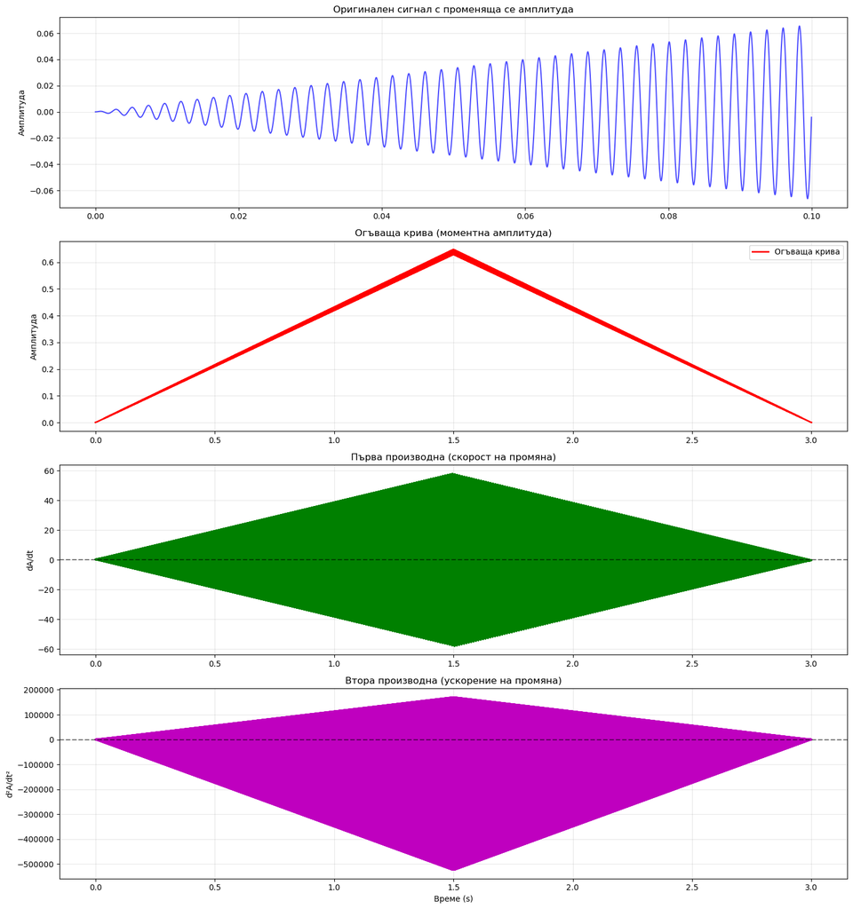

```
Анализ на динамиката:
-------------------------
Максимална скорост на нарастване: 58.0215
Максимална скорост на намаляване: -58.0215
Точки на прелом: 10518
  Точка 1: 0.006s
  Точка 2: 0.006s
  Точка 3: 0.006s
  Точка 4: 0.006s
  Точка 5: 0.007s
```

```python
# Импорти
import numpy as np
import matplotlib.pyplot as plt

# Анализ на динамиката чрез производни
def analyze_dynamics(signal, sample_rate=44100):
    """Анализира динамиката на музикален сигнал чрез производни"""

    # Изчисляване на моментната амплитуда (огъваща крива)
    envelope = np.abs(signal)

    # Изглаждане на огъващата крива
    window_size = sample_rate // 100  # 10ms прозорец
    envelope_smooth = np.convolve(envelope, np.ones(window_size)/window_size, mode='same')

    # Първа производна (скорост на промяна на амплитудата)
    dt = 1 / sample_rate
    first_derivative = np.gradient(envelope_smooth, dt)

    # Втора производна (ускорение на промяна на амплитудата)
    second_derivative = np.gradient(first_derivative, dt)

    return envelope_smooth, first_derivative, second_derivative

# Генериране на сигнал с променяща се амплитуда
def generate_dynamic_signal(duration=3.0, sample_rate=44100):
    """Генерира сигнал с променяща се амплитуда"""
    t = np.linspace(0, duration, int(sample_rate * duration), False)

    # Основна вълна
    frequency = 440
    base_wave = np.sin(2 * np.pi * frequency * t)

    # Променяща се амплитуда (crescendo следвано от diminuendo)
    amplitude_envelope = np.where(t < duration/2,
                                 t / (duration/2),  # crescendo
                                 2 - t / (duration/2))  # diminuendo

    # Комбиниране
    dynamic_signal = amplitude_envelope * base_wave

    return t, dynamic_signal

# Генериране и анализ
t, dyn_signal = generate_dynamic_signal()
envelope, first_deriv, second_deriv = analyze_dynamics(dyn_signal)

# Визуализация
fig, axes = plt.subplots(4, 1, figsize=(15, 16))

# Оригинален сигнал
axes[0].plot(t[:4410], dyn_signal[:4410], 'b-', alpha=0.7)
axes[0].set_title('Оригинален сигнал с променяща се амплитуда')
axes[0].set_ylabel('Амплитуда')
axes[0].grid(True, alpha=0.3)

# Огъваща крива
axes[1].plot(t, envelope, 'r-', linewidth=2, label='Огъваща крива')
axes[1].set_title('Огъваща крива (моментна амплитуда)')
axes[1].set_ylabel('Амплитуда')
axes[1].legend()
axes[1].grid(True, alpha=0.3)

# Първа производна
axes[2].plot(t, first_deriv, 'g-', linewidth=2)
axes[2].set_title('Първа производна (скорост на промяна)')
axes[2].set_ylabel('dA/dt')
axes[2].grid(True, alpha=0.3)
axes[2].axhline(y=0, color='black', linestyle='--', alpha=0.5)

# Втора производна
axes[3].plot(t, second_deriv, 'm-', linewidth=2)
axes[3].set_title('Втора производна (ускорение на промяна)')
axes[3].set_xlabel('Време (s)')
axes[3].set_ylabel('d²A/dt²')
axes[3].grid(True, alpha=0.3)
axes[3].axhline(y=0, color='black', linestyle='--', alpha=0.5)

plt.tight_layout()
plt.show()

# Анализ на критичните точки
# Намиране на максимуми и минимуми в първата производна
zero_crossings = []
for i in range(1, len(first_deriv)-1):
    if (first_deriv[i-1] > 0 and first_deriv[i+1] < 0) or \
       (first_deriv[i-1] < 0 and first_deriv[i+1] > 0):
        zero_crossings.append(i)

print("Анализ на динамиката:")
print("-" * 25)
print(f"Максимална скорост на нарастване: {np.max(first_deriv):.4f}")
print(f"Максимална скорост на намаляване: {np.min(first_deriv):.4f}")
print(f"Точки на прелом: {len(zero_crossings)}")

for i, zc in enumerate(zero_crossings[:5]):  # Показваме първите 5
    time_point = t[zc]
    print(f"  Точка {i+1}: {time_point:.3f}s")
```